# Data Visualization - HW1 - IE360

## 2) Weekly USD/TL Value in between 2015 and 2020

Since the Dollar / TL parity is constantly changing, it is a data ready to be examined. Fluctuations in Dollar / TL parity are easily noticed in Google searches. People have panic when the dollar is out of the expected trend. The boxplot graph of the last five-year value of the USD / TL parity is shown.

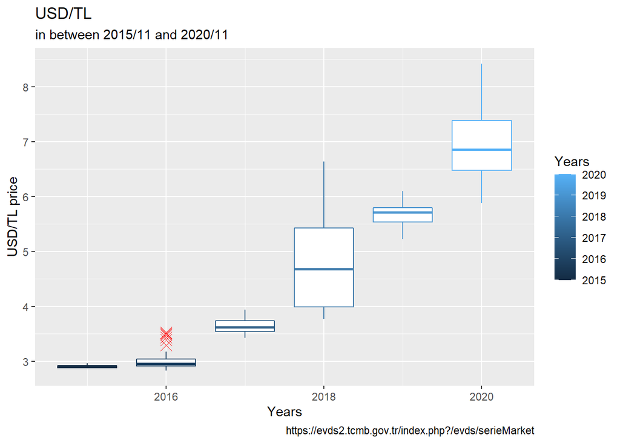

“Döviz”, “Dolar” , “Dolar Kaç Oldu” are especially frequently asked questions in Google search but also another encountered search in Google is “yurtdısında yasamak”

[figure not shown]

The histogram graph of ‘yurtdısında yasamak’ keyword is given below.

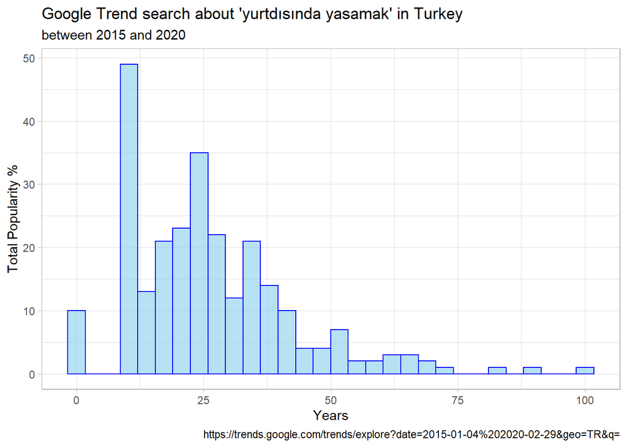